# Rmarkdown_16S_Ananlysis_mibibio

Simon Vandersanden

2026-03-05

## Loading in the necessary libraries for basic handeling

```r
library(phyloseq)
library(dplyr)
library(picante)    # For Phylogenetic Diversity
library(microbiome) # For Dominance metrics
```

```r
library(vegan)      # For Rarefaction curves
library(zCompositions)
library(ggplot2)
library(ggrepel)
library(MicrobiomeStat)
library(scales)
library(paletteer)
library(stringr)
```

## 1:Loading in and inspecting the different parts of the phyloseq object

Here you load in you microbiome data, there is a part where sample data can be linked to the object, so you can quickly add in new sample data for analysis and plotting.

```r
# Load in the phyloseq object
mibi_phylo_object <- readRDS("data/ps_IdTax_noncontam_NoMitChlo_Tree.rds")
# To see the OTU table
mibi_otu_table<- as(otu_table(mibi_phylo_object), "matrix")
#head(mibi_otu_table[,1:5])
# To see the Taxonomy
mibi_tax_table <- as(tax_table(mibi_phylo_object), "matrix")
#head(mibi_tax_table)
# To see the Metadata
mibi_meta_table <- as(sample_data(mibi_phylo_object), "data.frame")
# head(mibi_tax_table)

# You can also swap the metadata table, in case you want to make adjustments to the grouping of the samples or add some new metadata the the specific samples
mibi_meta_table_new <- read.table("data/META_Griftpark_Soilcore_Measurements.txt", header = T, sep = "\t", row.names = 1, stringsAsFactors = FALSE, dec = ',')
# Make sure the rownames of the loaded in metadata match the sample names in the phyloseq object
stopifnot(all(sample_names(mibi_phylo_object) %in% rownames(mibi_meta_table_new)))
sample_data(mibi_phylo_object) <- mibi_meta_table_new # Here you add the new sample data to the object, you can also add a new phylogenetic tree. with: phy_tree(mibi_phylo_object).
# After this step you have the otu count table information, the taxonomy table, phylogenetic tree and the correct or an updated version of the metadata.
```

## 2.1:Data Pre-processing: Filtering out all non-samples and checking rarefaction curves

Normally some pre-filtering has been done on the reads before they were put into the phyloseq object: the sequencing depth threshhold, the decontamination, and some taxonomic filtering of certain undesired taxa such as Eukaryota, Mitochondria and Chloroplast sequences. ### Here we can remove some unecessary samples from the dataset. ### There is also the possibility to plot the rarefaction curves, to see wheter the sequencing depth is sufficiënt.

```
## Calculating rarefaction curves... this may take a moment.
```

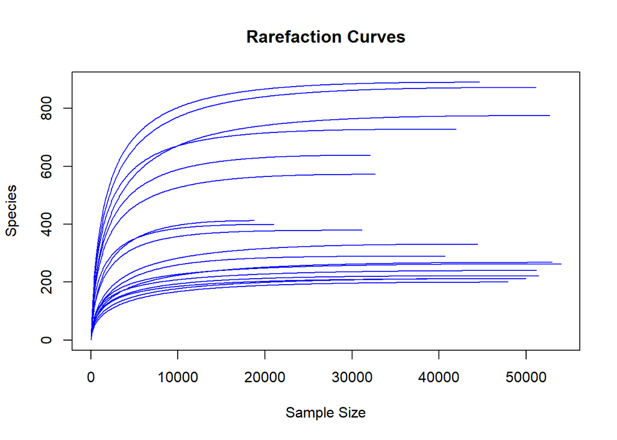

```r
# It is possible that that some blancs and mock samples are still present in the samples, these should be filtered out because we will only filter using all the 'real samples'
#filter out these blanc samples:
samples_to_remove <- c("Blank", "MockB", "nosample1", "nosample2", "nosample3", "nosample4")
mibi_phylo_object <- prune_samples(
  !(sample_names(mibi_phylo_object) %in% samples_to_remove),
  mibi_phylo_object
)
# Check the rarefaction curves:
#Requires: mibi_phylo_object
source("scripts/02_rarefaction_curves.R")
```

## 2.1:Data Pre-processing: Filtering out based on prevalence and abundance

Often prevalence or abundance filtering is done to remove uncertain features which can be artifacts created. or remove rare sequences, which might not be of interest to us. This is highly customisable so also all features can be kept however often for clarity, features are filtered out. Here you can filter on prevalence and abundance, you can also select either prevalence or either abundance.

```r
# --- Filtering parameters:USER INPUT SECTION ---
# Thresholds
# Usually filtering is done both on prevalence and abundance, for example, at least >10 reads in 3 samples.
prev_filter_threshold = 3   # Present in at least X samples
abund_filter_threshold = 5 # At least X reads

# Logic Switches (1 = On, 0 = Off)
  # Here you can specify which filtering must be done with 0 or 1 logic
prev_filter = 1
abund_filter = 1
# --------------------------
# Run the background script
# Requires: mibi_phylo_object, prev_filter_threshold, abund_filter_threshold...
source("scripts/02_filtering_prevalence_abundance.R")
```

```
## --- Filtering Summary ---
```

```
## Criteria: Combined (min 5 reads in 3 samples)
```

```
## Taxa before: 4427
```

```
## Taxa after:  964
```

```
## Percent kept: 21.78%
```

```r
#The script starts with taking the mibi_phylo_object and makes the:
#The resulting object 'mibi_phylo_object_filt' is now ready
```

## 2.1:Data Pre-processing: Filtering based on variance OPTIONAL, !!!This is not working yet!!!Also this should not be used for alpha or beta diversity, However it might be usefull before differential abundance analysis

```r
#Check the distribution of the varriances
otu <- as.matrix(microbiome::abundances(mibi_phylo_object_filt))
taxon_variance <- apply(otu, 1, IQR)
taxon_variance <- apply(as.matrix(microbiome::abundances(mibi_phylo_object_filt)), 1, IQR)> quantile(taxon_variance, probs = seq(0, 1, 0.05))
#This will remove a lot of taxa, since there will be many taxa with 0 variance because they only occur in one sample.
# --- Filtering parameters: USER INPUT SECTION ---
# Variance Cutoff (e.g., 0.1 removes the bottom 10% least variable taxa)
variance_cutoff = 0.00

# Logic Switch (1 = On, 0 = Off)
variance_filter_switch = 1
# --------------------------
# Run the background script
source("scripts/02_filtering_variance.R")
```

```
## Filtering applied: Low variance (Interquartile Range). (Threshold was 0; dropped all absolute zero-variance taxa)
```

```
## Variance Filter: Excluded the bottom 0% taxa. Removed: 626 ASVs.
## Final taxa count: 338
```

```r
#This script starts with mibi_phylo_object_filt and updates it with this filtering
# The resulting object 'mibi_phylo_object_filt' is now updated
```

## 2.1:Data Pre-processing: Sample removal or subset selection

If you have a large dataset or are interested in specific samples, here you can select which samples or groups of samples you want to take a closer look at.

```r
# Define the target group you want to subset
target_group = 'SC6'
# 1. Subset the samples, here you select the collumn you want to take the specific target group from.
mibi_phylo_object_subset <- subset_samples(mibi_phylo_object_filt, SC_Number == target_group)

# 2. Corrected Pruning: Sum the counts within the NEW subset
# This ensures that if an ASV only existed in 'SC1', it is removed from the 'SC2' object. So here you will prune out all taxa which are not found in the defined subset to ensure there is no trouble with these down the road.
mibi_phylo_object_subset <- prune_taxa(taxa_sums(mibi_phylo_object_subset) > 0, mibi_phylo_object_subset)

# 3. Reporting : An update on what was filtered, and how many taxa are left in this filtered object compared to the initial dataset.
message(paste("Subset selected:", target_group))
```

```
## Subset selected: SC6
```

```r
message(paste("Samples remaining:", nsamples(mibi_phylo_object_subset)))
```

```
## Samples remaining: 3
```

```r
message(paste("Taxa present in all samples:", ntaxa(mibi_phylo_object_filt)))
```

```
## Taxa present in all samples: 338
```

```r
message(paste("Taxa remaining after pruning zeros:", ntaxa(mibi_phylo_object_subset)))
```

```
## Taxa remaining after pruning zeros: 131
```

## 2.2 Object selection: selecting the object for the normalisation, and further data analysis.

```r
# Define which object flows into the analysis scripts
# Options: mibi_phylo_object_filt (full) or mibi_phylo_object_subset (subset)
ps_work <- mibi_phylo_object_filt
```

# 2.2:Data Pre-processing: Normalisation ## 3.0 Normalization & The “Zero Problem”

Microbiome data is **compositional**. Because total read counts are an artifact of sequencer depth, they represent “parts of a whole” rather than absolute concentrations. If one taxon blooms, others appear to decrease simply because they occupy a smaller percentage of the total pool.

### 3.1 Handling Sparsity (Zero Imputation)

Log-ratio transformations (like CLR) cannot handle zeros because $\log(0)$ is undefined. We address this using two distinct approaches before transformation:

- **Simple Pseudo-count (+1):** Adds a constant shift of 1 to every cell. It is fast and robust, though it can slightly bias ratios in extremely sparse datasets.
- **Bayesian-Multiplicative Replacement (BMR):** Uses the `zCompositions` package to impute zeros based on a Dirichlet prior. This is more mathematically rigorous as it preserves the ratio structure of the data.
  - **Note:** BMR requires careful handling of “singletons.” We have adjusted the `z.delete` and `z.warning` thresholds to ensure samples with limited diversity are not dropped during the imputation process.
- **Matrix Completion:** *Planned for future implementation.*

### 3.2 Executed Transformations

The following background script processes the chosen `ps_work` object and generates the normalized data structures, using different methods.

```r
# Requires: ps_work (defined in the data pre-processing section)
source("scripts/03_normalisation.R")
```

```
## Attempting BMR zero-imputation with microbiome-specific settings...
```

```
## No. adjusted imputations:  3059
```

```
## BMR successful: Imputed counts integrated.
```

```
## --- Normalization Summary ---
```

```
## 1. TSS: Relative abundance (0-100%) created.
```

```
## 2. Pseudo-CLR: Fast +1 shift transformation created.
```

```
## 3. BMR-CLR: Bayesian-imputed transformation created.
```

```r
#The following objects are created: each with a different data normalisation method.
#mibi_tss
#mibi_pseudo_clr
#mibi_bmr_clr
```

###The script generates three primary objects. Choosing the right one depends on your specific analysis:

-mibi_tss Total Sum Scaling Visualization: Relative Abundance (%) used for stacked bar plots.

-mibi_pseudo_clr Pseudo-CLR (+1) Statistics: Fast transformation for PCoA and basic linear modeling.

-mibi_bmr_clr BMR-CLR (Bayesian) Advanced Stats: High-fidelity modeling and differential abundance.

# Community visualisation: barplots

This chunk is designed to plot relative abundances of you microbial community data, this takes the microbial community and you can select at which level the plotting is done, the labeling is two levels to ensure comprehensiveness, and detail (higher phylogenetic level and lower for the detail). The main color is determined by the high level taxonomy, variations of this main color are used in the lower levels. Several choices can be made, a relative abundance threshold level, which is a cutoff level for relative abundance, if a taxon does not meet this threshold i.e. all taxa with relative abundance below this threshold are put into ‘Others’

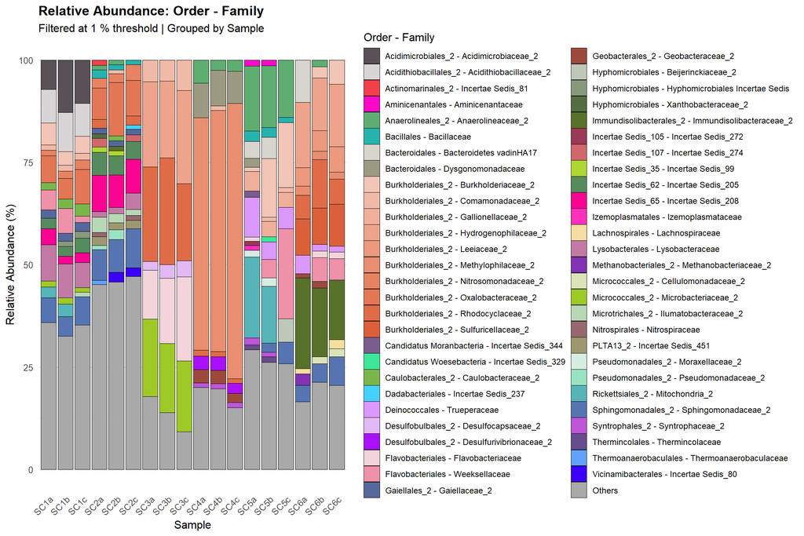

```r
# --- SETUP, load in the script that is the code backbone of this part ---
source("scripts/08_barchart_visualisation.R")
# --- 1. INPUT ---
# specify the plot specifics:
high_level <- "order" # Specify the high taxonomic level
low_level  <- "family" # Specify the lower taxonomic level
facet_var  <- "Sample" # or "Grouping_SC or Sample"
threshold  <- 1 # Specify the relative abundance threshold from which the taxa are filtered
pal_choice  <- "pals::polychrome" # Define the color pallet to use
# --- 2. CREATION OF THE OBJECT FOR PLOTTING ---
# Here the previously defined taxa are put into the function that prepares the data for plotting.

data_for_plot <- prepare_abundance_data(
  ps         = ps_work, #Here you specify the phyloseq object which you want to plot from
  high_level = high_level,
  low_level  = low_level,
  facet_var  = facet_var,
  threshold  = threshold )

# This prepared the colours, so custom colours are assigned to the created groups depending on the taxonomic specification.
my_colors <- get_shaded_palette(data_for_plot, pal_choice)

# --- 3. DYNAMIC PLOTTING ---
# This is a complex plotting command that is constructed to take into acount the previously specified parameters, high and low taxonomic levels, relative abundance threshold cutoff, how to group the samples for plotting. So this information is also found on the finally generated plot
Relative_Abundance_Plot <- ggplot(data_for_plot, aes(x = !!sym(facet_var), y = Abundance, fill = Hierarchical_Label)) +
  geom_bar(stat = "identity", position = "stack", color = "black", size = 0.05) +
  scale_fill_manual(values = my_colors) +
  labs(    title = paste("Relative Abundance:", str_to_title(high_level), "-", str_to_title(low_level)),
    subtitle = paste("Filtered at", threshold, "% threshold | Grouped by", facet_var),
    x = str_replace_all(facet_var, "_", " "),
    y = "Relative Abundance (%)",
    fill = paste(str_to_title(high_level), "-", str_to_title(low_level))
  ) +
  theme_minimal(base_size = 12) +
  theme(
    axis.text.x = element_text(angle = 45, vjust = 1, hjust = 1),
    legend.text = element_text(size = 9),
    panel.grid.major.x = element_blank(),
    plot.title = element_text(face = "bold")
  ) +
  guides(fill = guide_legend(ncol = 2))
# Display the plot and save a copy in the results tab
Relative_Abundance_Plot
```

```r
ggsave(paste0("results/Relative_Abundance_Plot_", high_level, "_",low_level , ".png"), plot = Relative_Abundance_Plot, width = 12, height = 8, dpi = 300)
```

## Community visualisation, detailed group analysis.

This chunk of code is designed to plot relative abundances of you microbial community data. But here you can look within specific group and get the lower level taxonomic distribution so you can gain insights into specific important groups within you data.The labeling is two levels to ensure comprehensiveness, and detail (higher phylogenetic level and lower for the detail). The main color is determined by the high level taxonomy, variations of this main color are used in the lower levels. Several choices can be made, a relative abundance threshold level, which is a cutoff level for relative abundance, if a taxon does not meet this threshold i.e. all taxa with relative abundance belower this threshold are put into ‘Others’

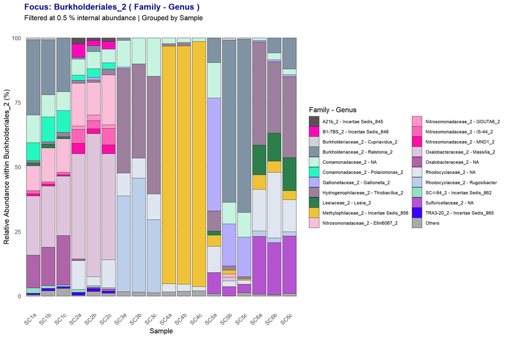

```r
# --- SETUP, load in the script that is the code backbone of this part ---
source("scripts/08_barchart_specific_group.R")
# --- 1. DEFINE SPECIFICS ---
# These two inputs are specific for this script. Here you select which specific taxon you want to take a closer look at
target_rank <- "order" # "family", "order", "class" "phylum"
target_val  <- "Burkholderiales_2" # select the specific group within the target rank e.g. Pseudomonadota for the phylum. Burkholderiales for order

# From this specifically selected group there is the possibility to plot the lower taxonomic levels within it, similar logic to a normal relative abundance plot, but now the relative abundance within this selected taxonomic group is plotted.

high_level  <- "family"
low_level   <- "genus"
facet_var   <- "Sample"
threshold   <- 0.5
pal_choice  <- "pals::polychrome"

# --- 2. CREATION OF THE OBJECT FOR PLOTTING ---

data_subset <- prepare_specific_abundance_data(
  ps         = ps_work,
  rank_name  = target_rank,
  rank_value = target_val,
  high_level = high_level,
  low_level  = low_level,
  facet_var  = facet_var,
  threshold  = threshold
)

# This prepared the colors, so custom colors are assigned to the created groups depending on the taxonomic specification.
my_colors_sub <- get_shaded_palette(data_subset, pal_choice)# Uses the shared function from: 08_barchart_visualisation.R

# --- 3. DYNAMIC PLOTTING ---
# This is a complex plotting command that is constructed to take into acount the previously specified parameters, high and low taxonomic levels, relative abundance threshold cutoff, how to group the samples for plotting. So this information is also found on the finally generated plot
Specific_Group_Relative_Abundance_Plot <- ggplot(data_subset, aes(x = !!sym(facet_var), y = Abundance, fill = Hierarchical_Label)) +
  geom_bar(stat = "identity", position = "stack", color = "black", size = 0.05) +
  scale_fill_manual(values = my_colors_sub) +
  labs(
    title = paste("Focus:", target_val, "(", str_to_title(high_level), "-", str_to_title(low_level), ")"),
    subtitle = paste("Filtered at", threshold, "% internal abundance | Grouped by", facet_var),
    x = stringr::str_replace_all(facet_var, "_", " "),
    y = paste("Relative Abundance within", target_val, "(%)"),
    fill = paste(str_to_title(high_level), "-", str_to_title(low_level))
  ) +
  theme_minimal(base_size = 12) +
  theme(
    axis.text.x = element_text(angle = 45, vjust = 1, hjust = 1),
    legend.text = element_text(size = 8),
    panel.grid.major.x = element_blank(),
    plot.title = element_text(face = "bold", color = "darkblue")
  ) +
  guides(fill = guide_legend(ncol = 2))

# Display the plot and save a copy in the results tab
Specific_Group_Relative_Abundance_Plot
```

```r
ggsave(paste0("results/Specific_Group_Relative_Abundance_Plot_", target_val, ".png"), plot = Specific_Group_Relative_Abundance_Plot, width = 12, height = 8, dpi = 300)
```

## 4.0 Alpha Diversity: Community Trait Analysis

Alpha diversity describes the complexity of a microbial community within a single sample. Rather than looking at “who is there,” we look at the mathematical properties of the population structure. We categorize these traits into four pillars:

- **Richness:** The total number of unique taxa observed (how many species?).
- **Dominance:** Measures if the community is “top-heavy” with one or two abundant taxa.
- **Evenness:** How equally the individuals are distributed among the species.
- **Information:** Mathematical indices (like Shannon) that balance both richness and evenness.

> **Important:** Alpha diversity calculations are sensitive to normalization. We use the filtered, non-transformed object (`mibi_phylo_object_filt`) to ensure we are counting physical reads, not mathematical ratios.

```r
# 1. Input Object (Filtered counts)
alfa_diversity_phyloseq_object <- mibi_phylo_object_filt

# 2. USER INPUT: Select Community Traits
selected_richness    <- c('observed', 'chao1')
selected_dominance   <- c('absolute', 'dbp')
selected_evenness    <- c('pielou')
selected_information <- c('shannon')

# 4. Run Scripts
source("scripts/04_alpha_diversity.R")
```

```
## Observed richness
```

```
## Other forms of richness
```

```
## Diversity
```

```
## Evenness
```

```
## Dominance
```

```
## Rarity
```

```
## Alpha diversity calculation complete.
```

```r
#We visualize the distribution of community traits across our experimental groups. Note that the Y-axis scales are "free" because the units for Richness (counts) and Dominance (0-1) are fundamentally different.

# 3. USER INPUT: Plotting Configuration
plot_x_axis   <- "SC_Number" #  What is on the X-axis? (e.g., "Timepoint", "group")
plot_color_by <- "SC_Number" # What defines the colors? (e.g., "group", "replicate")
plot_cols     <- 2              # Number of columns in the plot grid
plot_metrics <- plot_metrics_all
#plot_metrics <- c("observed", "shannon") # Use all calculated, or specific ones: c("observed", "shannon")
source("scripts/04_alpha_plots.R")
```

```
## Alpha plot generated.
```

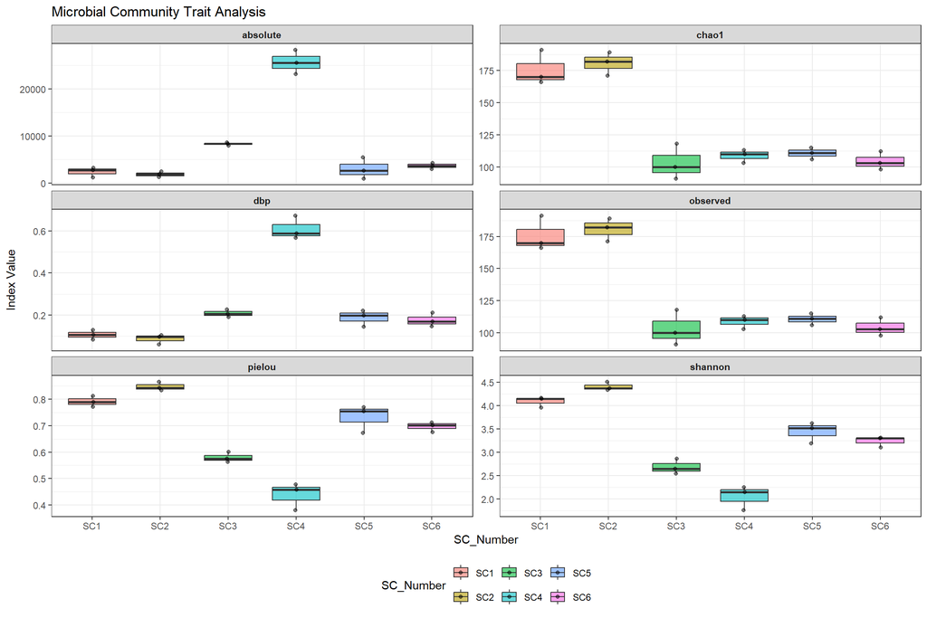

```r
# Display the plot and save a copy in the results tab
plot(alpha_boxplot)
```

```r
ggsave("results/alpha_diversity_plot.png", alpha_boxplot, width = 12, height = 8, dpi = 300)
```

## 5.0 Beta Diversity: Community Dissimilarity

Beta diversity quantifies the “distance” or “dissimilarity” between pairs of samples. To provide a non-redundant overview, we categorize these metrics based on whether they consider abundance (quantitative) vs. presence (qualitative), and phylogeny (evolutionary relatedness).

- **Aitchison:** Euclidean distance on CLR-transformed data. The gold standard for compositional data.
- **Bray-Curtis:** Non-phylogenetic; accounts for abundance.
- **Jaccard:** Non-phylogenetic; accounts only for presence/absence.
- **UniFrac (Weighted/Unweighted):** Phylogenetic; accounts for evolutionary distances between taxa.

> **Note:** For Aitchison, we use the CLR-imputed objects. For Bray, Jaccard, and UniFrac, we use Total Sum Scaling (TSS) to ensure sequencing depth doesn’t bias the distances.

```r
# --- USER INPUT: Beta Diversity Configuration ---
beta_metric = "wunifrac"    # Options: "aitchison", "bray", "jaccard", "unifrac", "wunifrac"
clr_variant = "BMR"         # If using Aitchison, select: "BMR" or "pseudo"
color_var   = "Groundwater_level"    # Metadata column for grouping/colors
shape_var   = NULL           # Optional: Metadata column for shapes (or NULL)
group_clustering <- "Groundwater_level"
shape_var <- "SC_Number"
# 1. Run Calculation (Ordination & PERMANOVA)
source("scripts/05_beta_diversity_calc.R")
```

```
## Calculating: wunifrac Distance (PCoA) on TSS data
```

```r
# 2. Run Visualization
source("scripts/05_beta_diversity_visualisation.R")
```

```
## Beta diversity plot with labels generated.
```

```
## Beta diversity plot generated.
```

[figure not shown]

```r
# Display Plot and PERMANOVA results
plot(p_beta)
```

```r
# Plots are saved within the .R script with and without sample labels
```

## 5.2 Advanced Ordination: Environmental Correlation PCA variant

#In this section, we upgrade the ordination by mapping environmental variables (vectors) and group shapes (hulls) onto the microbial landscape.

```r
# --- USER INPUT: Beta Diversity Configuration ---
beta_metric      <- "aitchison" # only aitchison possible since it is PCA ordination
clr_variant      <- "BMR"
color_var        <- "Groundwater_level"
group_clustering <- "Groundwater_level"
shape_var        <- "SC_Number"

# 1. Run Calculation (Ordination & PERMANOVA)
source("scripts/05_beta_diversity_calc.R")
```

```
## Calculating: Aitchison Distance (PCA) using BMR imputation
```

```r
# UPGRADING OPTIONS, for env fit:
head(ps_beta_input@sam_data)
```

```
##       Primerpairname       ForwardPrimer        ReversePrimer SampleID.1
## SC1a 515fimp-806rimp GTGYCAGCMGCCGCGGTAA GGACTACNVGGGTWTCTAAT      SC1_a
## SC1b 515fimp-806rimp GTGYCAGCMGCCGCGGTAA GGACTACNVGGGTWTCTAAT      SC1_b
## SC1c 515fimp-806rimp GTGYCAGCMGCCGCGGTAA GGACTACNVGGGTWTCTAAT      SC1_c
## SC2a 515fimp-806rimp GTGYCAGCMGCCGCGGTAA GGACTACNVGGGTWTCTAAT      SC2_a
## SC2b 515fimp-806rimp GTGYCAGCMGCCGCGGTAA GGACTACNVGGGTWTCTAAT      SC2_b
## SC2c 515fimp-806rimp GTGYCAGCMGCCGCGGTAA GGACTACNVGGGTWTCTAAT      SC2_c
##      SC_Number   SID Group_name Description DNA_quantity Sample_or_Control
## SC1a       SC1 groen      groen       test2         1000       True Sample
## SC1b       SC1 groen      groen       test2         1000       True Sample
## SC1c       SC1 groen      groen       test2         1000       True Sample
## SC2a       SC2 groen      groen       test2         1000       True Sample
## SC2b       SC2 groen      groen       test2         1000       True Sample
## SC2c       SC2 groen      groen       test2         1000       True Sample
##      Order.Treatment Groundwater_level   pH Conductivity Sample.depth
## SC1a              37             above 8.85         0.08          2.5
## SC1b              38             above 8.85         0.08          2.5
## SC1c              39             above 8.85         0.08          2.5
## SC2a              40             above 8.58         0.12          3.0
## SC2b              41             above 8.58         0.12          3.0
## SC2c              42             above 8.58         0.12          3.0
##      Av_Nitrate.J.kg. Av_Manganese.J.kg. Av_Iron.J.kg. Av_Sulphate.J.kg.
## SC1a         62.44194           142.9781      1205.694          26.84989
## SC1b         62.44194           142.9781      1205.694          26.84989
## SC1c         62.44194           142.9781      1205.694          26.84989
## SC2a         72.04839           245.1054      3242.734          52.15074
## SC2b         72.04839           245.1054      3242.734          52.15074
## SC2c         72.04839           245.1054      3242.734          52.15074
##      Av_Total_Energy.J.kg. SUM.PAHs..EPA. OrderTreatment Groundwater
## SC1a              2625.957              0             15    Above_GW
## SC1b              2625.957              0             16    Above_GW
## SC1c              2625.957              0             17    Above_GW
## SC2a              4800.032            110             18    Above_GW
## SC2b              4800.032            110             19    Above_GW
## SC2c              4800.032            110             20    Above_GW
##      PAH.polluted Grouping_SC Nitrate.benzene.oxidation.capacity..mg.kg.
## SC1a          Low         SC1                                   1.637790
## SC1b          Low         SC1                                   1.637790
## SC1c          Low         SC1                                   1.637790
## SC2a          Med         SC2                                   1.889758
```

[output cut: 15 more lines]

```
## SC2c                                411.6819
##      Sulphate.benzene.oxidation.capacity..mg.kg.
## SC1a                                    11.27551
## SC1b                                    11.27551
## SC1c                                    11.27551
## SC2a                                    21.90051
## SC2b                                    21.90051
## SC2c                                    21.90051
##      total.benzene.oxidation.capacity..mg.kg.
## SC1a                                 239.6709
## SC1b                                 239.6709
## SC1c                                 239.6709
## SC2a                                 449.6900
## SC2b                                 449.6900
## SC2c                                 449.6900
```

```r
env_variables    <- c("pH", "Av_Iron.J.kg.", "Conductivity", "SUM.PAHs..EPA.","total.benzene.oxidation.capacity..mg.kg.") # Continuous metadata
top_asv_n        <- 5    # Show top 5 ASVs driving the plot
target_level <- "order" #define taxonomic level which is given to the taxa, choose your level here: "genus", "family", "order", "class" "phylum", etc
# scalinglength of the arrows
arrow_reduction_taxa <- 5
arrow_reduction_env <- 2

# Run the advanced script
source("scripts/05_beta_advanced_vis_PCA.R")
```

```
## Upgraded PCA plot generated.
```

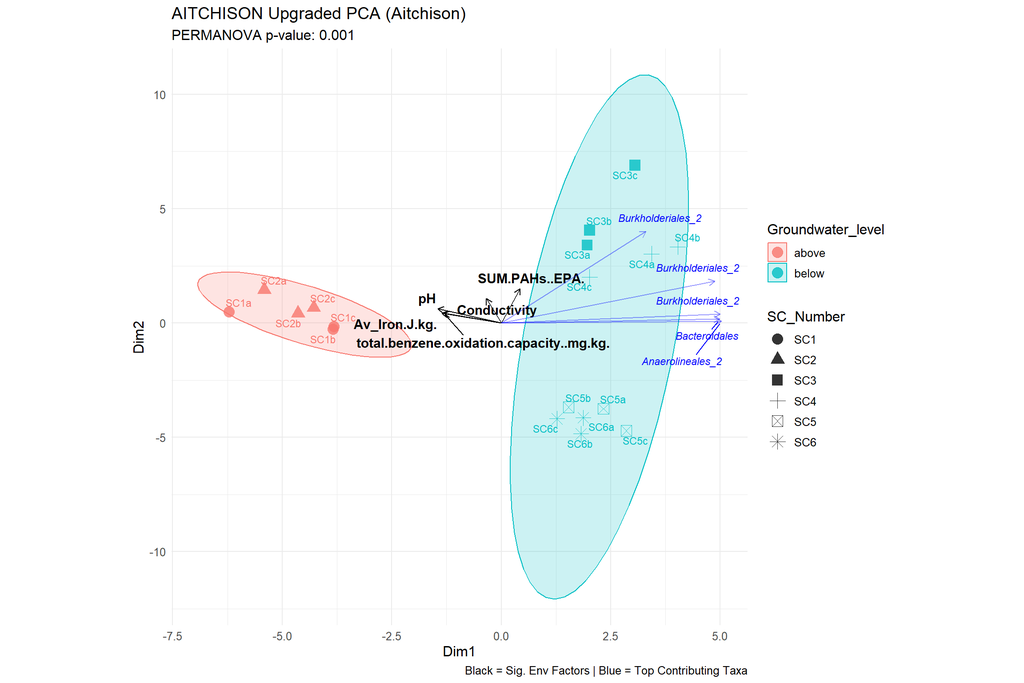

```r
# Display
plot(p_beta_PCA)
```

```r
# Plots are saved within the .R script with and without sample labels
```

## 5.3 Advanced Ordination: Environmental Correlation PCoA variant

```r
# --- USER INPUT: Beta Diversity Configuration ---
beta_metric      <- "wunifrac" # Or "bray", "jaccard", "unifrac"
color_var        <- "Groundwater_level"
group_clustering <- "Groundwater_level"
shape_var        <- "SC_Number"
# 1. Run Calculation (Ordination & PERMANOVA)
source("scripts/05_beta_diversity_calc.R")
```

```
## Calculating: wunifrac Distance (PCoA) on TSS data
```

```r
# UPGRADING OPTIONS:
env_variables    <- c("pH", "Av_Iron.J.kg.", "Conductivity", "SUM.PAHs..EPA.","total.benzene.oxidation.capacity..mg.kg.")
top_asv_n        <- 5    # Show top 5 ASVs driving the plot
target_level <- "class" #define taxonomic level which is given to the taxa, choose your level here: "genus", "family", "order", "class" "phylum", etc
# scalinglength of the arrows
arrow_reduction_taxa <- 0.2
arrow_reduction_env <- 0.1

# Run the PCoA-specific visualization
source("scripts/05_beta_advanced_vis_PCoA.R")
```

[output not shown]

```
## PCoA Upgraded plot successfully generated using SV base logic.
```

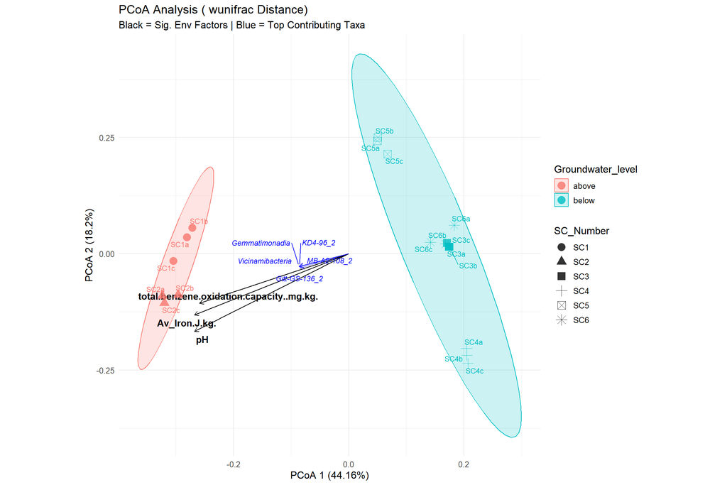

```r
# Display
plot(p_beta_PCoA)
```

## 6. Differential_abundance_LinDA.R

In this script we do a differential abundance analysis. In the following chunk calculations are made.

```r
# We use the filtered and not normalised phyloseq object, since LinDA handels the normalisation
# To make plots readable agglomerate at the selected phylogenetic level
# select the phylogenetic level to what the taxa should be agglomerated.
target_level_linda <- "family" # "species", "genus", "family", "order", "class" "phylum"
source("scripts/06_preparing_object_for_Linda.R")

# Set your primary comparison and reference group
main_var <- "Groundwater" # Adjust to match your exact metadata column name
ref_group <- "Below_GW" #ref_group <- "Below_GW" , depending on the levels of a specific factor.

# Set Reference
meta_df[[main_var]] <- relevel(factor(meta_df[[main_var]]), ref = ref_group)
# Define Formula: This model identifies which bacteria significantly change their abundance in response to the parameters defined in the model:
# Here: Main Effects + Interaction + Random Effect for replicates
# Grouping_SC = SC1, SC2, etc. (the sampling points)
linda_formula <- "~ Groundwater* SUM.PAHs..EPA. + (1 | SC_Number)"

#Run Linda:
# LinDA will drop these anyway, but it's good to be aware.
linda_res <- linda(
  feature.dat = otu_tab,
  meta.dat = meta_df,
  formula = linda_formula,
  feature.dat.type = "count",
  prev.filter = 0.10,        # Equivalent to your prev.cut
  is.winsor = TRUE,          # Enables outlier replacement
  outlier.pct = 0.03,        # Percentage of outliers to winsorize (default)
  zero.handling = "imputation", # imputation method, either 'pseudo-count' or imputation, exact imputation strategy can be found here: https://link.springer.com/article/10.1186/s13059-022-02655-5
  pseudo.cnt = 0.5,
  alpha = 0.05,              # FDR significance level
  p.adj.method = "BH"        # Benjamini-Hochberg adjustment
)
```

```
## 0  features are filtered!
## The filtered data has  18  samples and  137  features will be tested!
## Pseudo-count approach is used.
## Fit linear mixed effects models ...
## Completed.
```

```r
# From this linda output you can plot multiple things
```

# Plotting the Linda results

The interpretation of these results must be done carefully depending on the Linda input, Think about the model formula, and reference level since these will be essential in interpreting the output

For example, if you are working with a model which includes an interaction term. If you specify the reference group as above groundwater, then if you plot the ‘SUM.PAHs..EPA.’ then you will get how the bacteria differ in log fold change as if the conditions were above groundwater.

Now if we are interested in how the bacteria differ in log fold changes with respect to PAH level below groundwater level, we need to change the reference group to below groundwater level to base the model on.

```r
## Plotting & Filtering
# Define which effect you want to visualize from names(linda_res$output)
# Example: "Groundwater_levelabove" or "SUM.PAHs..EPA." or the interaction
print(names(linda_res$output))
```

```
## [1] "GroundwaterAbove_GW"                "SUM.PAHs..EPA."
## [3] "GroundwaterAbove_GW:SUM.PAHs..EPA."
```

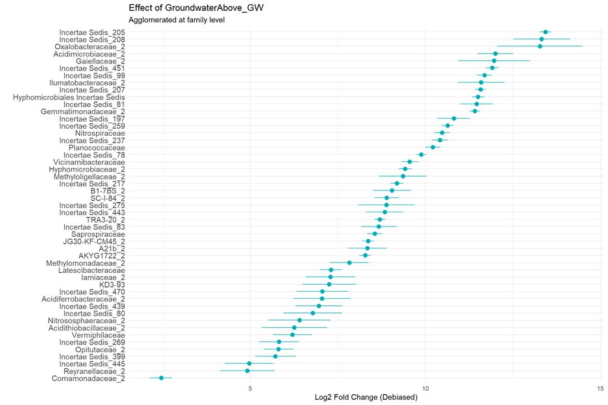

```r
var_to_plot <- "GroundwaterAbove_GW" #SUM.PAHs..EPA. or GroundwaterAbove_GW:SUM.PAHs..EPA., this is dependant on the model which was defined in the previous chunk

source("scripts/06_differential_abundance_LinDA.R")
```